# Data Description

Reference: https://www.kaggle.com/c/web-traffic-time-series-forecasting/data

```
Original data: train_1.csv
-----------------------------
rows = 145,063
columns = 551
first column = Page
date columns = 2015-07-01, 2015-07-02, ..., 2016-12-31 (550 columns)
file size: 284.6 MB


Data for time series
----------------------------------------------
selected year: 2016 (leap year 366 days)

selected time series:

The most visited page.
df['Page'] == """Special:Search_en.wikipedia.org_desktop_all-agents"""
```

**Notes**

- This notebook used `pmdarima` and this pmd-arima module needs special statsmodels so, create a new conda env for this.

```python
import numpy as np
import pandas as pd
import seaborn as sns
sns.set(color_codes=True)

import matplotlib
import matplotlib.pyplot as plt
%matplotlib inline
%config InlineBackend.figure_format = 'retina'
sns.set(context='notebook', style='whitegrid', rc={'figure.figsize': (12,8)})
plt.style.use('fivethirtyeight') # better than sns styles.
matplotlib.rcParams['figure.figsize'] = 12,8

import os
import time

# random state
random_state=100
np.random.seed(random_state)

# Jupyter notebook settings for pandas
#pd.set_option('display.float_format', '{:,.2g}'.format) # numbers sep by comma
from pandas.api.types import CategoricalDtype
np.set_printoptions(precision=3)
pd.set_option('display.max_columns', 100)
pd.set_option('display.max_rows', 100) # None for all the rows
pd.set_option('display.max_colwidth', 200)

import IPython
from IPython.display import display, HTML, Image, Markdown

import gc

import statsmodels
import statsmodels.api as sm
import statsmodels.formula.api as smf
import statsmodels.graphics.api as smg
import statsmodels.robust as smrb # smrb.mad() etc
import patsy # y,X1 = patsy.dmatrices(formula, df, return_type='dataframe')

# versions
import watermark
%load_ext watermark
%watermark -a "Bhishan Poudel" -d -v -m
print()
%watermark -iv
```

```
Bhishan Poudel 2020-10-14

CPython 3.7.9
IPython 7.18.1

compiler   : Clang 10.0.0
system     : Darwin
release    : 19.6.0
machine    : x86_64
processor  : i386
CPU cores  : 4
interpreter: 64bit

autopep8        1.5.4
statsmodels.api 0.11.1
statsmodels     0.11.1
matplotlib      3.1.3
pandas          1.1.1
patsy           0.5.1
watermark       2.0.2
seaborn         0.11.0
json            2.0.9
numpy           1.19.1
IPython         7.18.1
```

```python
%%javascript
IPython.OutputArea.auto_scroll_threshold = 9999;
```

# Useful Functions

```python
def show_methods(obj, ncols=4):
    lst = [i for i in dir(obj) if i[0]!='_' ]
    df = pd.DataFrame(np.array_split(lst,ncols)).T.fillna('')
    return df
```

MAPE - Mean Absolute Percentage Error: $$ M A P E=\frac{100}{n} \sum_{i=1}^{n} \frac{\left|y_{i}-\hat{y}_{i}\right|}{y_{i}} $$

SMAPE - Symmetric Mean Absolute Percentage Error:

$$ S M A P E=\frac{100 \%}{n} \sum_{t=1}^{n} \frac{\left|F_{t}-A_{t}\right|}{\left(\left|A_{t}\right|+\left|F_{t}\right|\right) / 2} $$$$ S M A P E=\frac{100 \%}{n} \sum_{i=1}^{n} \frac{\left|y_{i}-\hat{y}_{i}\right|}{\left(\left|y_{i}\right|+\left|\hat{y}_{i}\right|\right) / 2} $$

```python
def get_mape(y_true, y_pred):
    return np.mean(np.abs((y_true - y_pred) / y_true)) * 100

def get_smape(y_true, y_pred):
    denominator = (np.abs(y_true) + np.abs(y_pred))
    diff = np.abs(y_true - y_pred) / denominator
    diff[denominator == 0] = 0.0
    return 200 * np.mean(diff)
```

# Load the data

```python
df = pd.read_csv('../data/train_1.csv.zip',compression='zip')

cond = df['Page'] == """Special:Search_en.wikipedia.org_desktop_all-agents"""
df = df.loc[cond]
df = df.filter(regex="Page|2016")
df = df.melt(id_vars=['Page'],var_name='date',value_name='visits').drop('Page',axis=1)
df = df.dropna(how='any')

print(df.shape)
df.iloc[:2,:5]
```

```
(366, 2)
```

|  | date | visits |
| --- | --- | --- |
| 0 | 2016-01-01 | 1401667.0 |
| 1 | 2016-01-02 | 1395136.0 |

```python
df['date'] = pd.to_datetime(df['date'])
df['visits'] = df['visits'].astype(np.int32)
df = df[['visits','date']].set_index('date')

ts = df['visits']

ts.head()
```

```
date
2016-01-01    1401667
2016-01-02    1395136
2016-01-03    1455522
2016-01-04    1750373
2016-01-05    1787494
Name: visits, dtype: int32
```

```python
# make sure this is series, not dataframe
type(ts)
```

```
pandas.core.series.Series
```

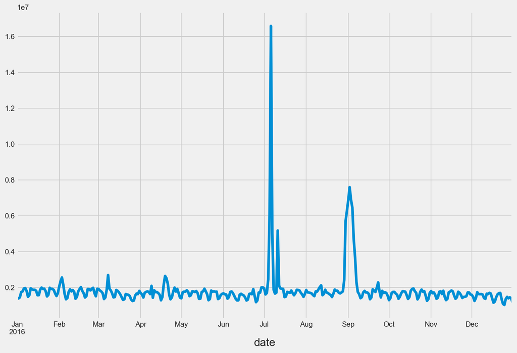

```python
ts.plot()
```

```python
# almost all values are around 0.2e7 except 3 peaks.
# these peaks will later harm timeseries modelling.
```

```python
ts.describe().T
```

```
count    3.660000e+02
mean     1.845918e+06
std      1.095724e+06
min      1.030746e+06
25%      1.515952e+06
50%      1.700576e+06
75%      1.821304e+06
max      1.659208e+07
Name: visits, dtype: float64
```

```python
t = ts[ts > 0.3e7]
t
```

```
date
2016-07-05     6038766
2016-07-06    16592075
2016-07-07     5025785
2016-07-11     5181746
2016-08-30     5700934
2016-08-31     6281005
2016-09-01     6878515
2016-09-02     7599524
2016-09-03     6894531
2016-09-04     6457072
2016-09-05     4705306
2016-09-06     3688959
Name: visits, dtype: int32
```

```python
# the wikipedia page visits seems to have weekly periodicity
# we can try replacing these possible outlier values with value from one week
# prior to them.
#
# attempt2:
# we can also fill these values with mean from given week day.
```

```python
idx = ts[ts > 0.3e7].index
idx
```

```
DatetimeIndex(['2016-07-05', '2016-07-06', '2016-07-07', '2016-07-11',
               '2016-08-30', '2016-08-31', '2016-09-01', '2016-09-02',
               '2016-09-03', '2016-09-04', '2016-09-05', '2016-09-06'],
              dtype='datetime64[ns]', name='date', freq=None)
```

```python
idx - pd.Timedelta(days=7)
```

```
DatetimeIndex(['2016-06-28', '2016-06-29', '2016-06-30', '2016-07-04',
               '2016-08-23', '2016-08-24', '2016-08-25', '2016-08-26',
               '2016-08-27', '2016-08-28', '2016-08-29', '2016-08-30'],
              dtype='datetime64[ns]', name='date', freq=None)
```

```python
ts[idx - pd.Timedelta(days=7)]
```

```
date
2016-06-28    1715507
2016-06-29    2010241
2016-06-30    2012923
2016-07-04    2457009
2016-08-23    1820624
2016-08-24    1825362
2016-08-25    1710625
2016-08-26    1676577
2016-08-27    1730368
2016-08-28    1788768
2016-08-29    2420356
2016-08-30    5700934
Name: visits, dtype: int32
```

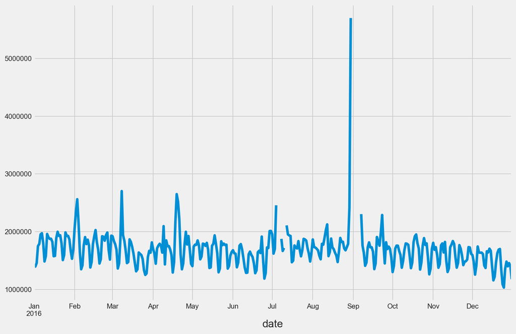

```python
ts_no_outliers = ts.copy()
ts_no_outliers[idx] = ts_no_outliers[idx - pd.Timedelta(days=7)]

ts_no_outliers.plot()
```

```python
# again i see only one peak, remove this peak
idx = ts[ts > 0.3e7].index
idx
```

```
DatetimeIndex(['2016-07-05', '2016-07-06', '2016-07-07', '2016-07-11',
               '2016-08-30', '2016-08-31', '2016-09-01', '2016-09-02',
               '2016-09-03', '2016-09-04', '2016-09-05', '2016-09-06'],
              dtype='datetime64[ns]', name='date', freq=None)
```

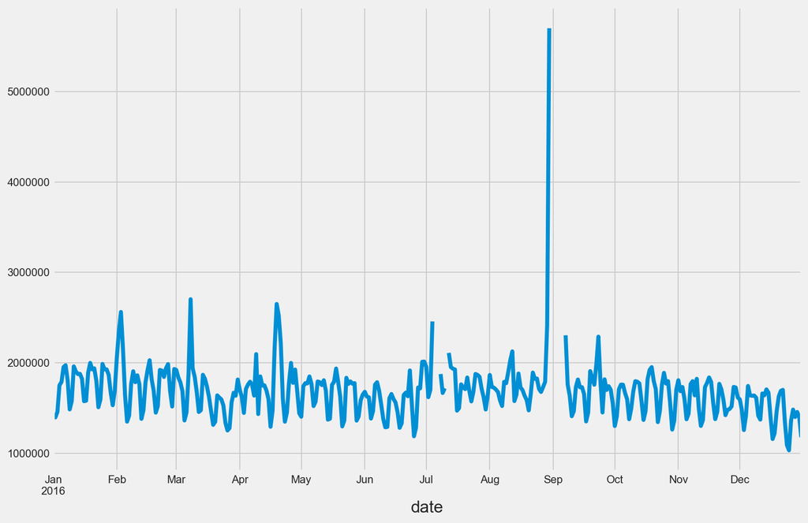

```python
ts_no_outliers[idx] = ts_no_outliers[idx - pd.Timedelta(days=7)]

ts_no_outliers.plot()
```

```python
ts_no_outliers.head().append(ts_no_outliers.tail())
```

```
date
2016-01-01    1401667.0
2016-01-02    1395136.0
2016-01-03    1455522.0
2016-01-04    1750373.0
2016-01-05    1787494.0
2016-12-27    1481319.0
2016-12-28    1399599.0
2016-12-29    1455447.0
2016-12-30    1397331.0
2016-12-31    1175657.0
Name: visits, dtype: float64
```

```python
ts_no_outliers.shape
```

```
(366,)
```

```python
# now try imputing outliers with given weekday mean.
```

```python
ts[ts>0.3e7]
```

```
date
2016-07-05     6038766
2016-07-06    16592075
2016-07-07     5025785
2016-07-11     5181746
2016-08-30     5700934
2016-08-31     6281005
2016-09-01     6878515
2016-09-02     7599524
2016-09-03     6894531
2016-09-04     6457072
2016-09-05     4705306
2016-09-06     3688959
Name: visits, dtype: int32
```

```python
ts_good_weekday_means = ts[ts<0.3e7].groupby(ts[ts<0.3e7].index.weekday).agg('mean')
ts_good_weekday_means
```

```
date
0    1.804507e+06
1    1.833039e+06
2    1.811539e+06
3    1.781031e+06
4    1.650711e+06
5    1.426800e+06
6    1.467813e+06
Name: visits, dtype: float64
```

```python
ts_bad_idx_weekday = ts[ts>0.3e7].index.weekday
ts_bad_idx_weekday
```

```
Int64Index([1, 2, 3, 0, 1, 2, 3, 4, 5, 6, 0, 1], dtype='int64', name='date')
```

```python
imputes = ts[ts>0.3e7].index.weekday.map(ts_good_weekday_means).to_numpy()
imputes
```

```
array([1833038.959, 1811539.16 , 1781030.9  , 1804507.3  , 1833038.959,
       1811539.16 , 1781030.9  , 1650711.058, 1426799.75 , 1467813.02 ,
       1804507.3  , 1833038.959])
```

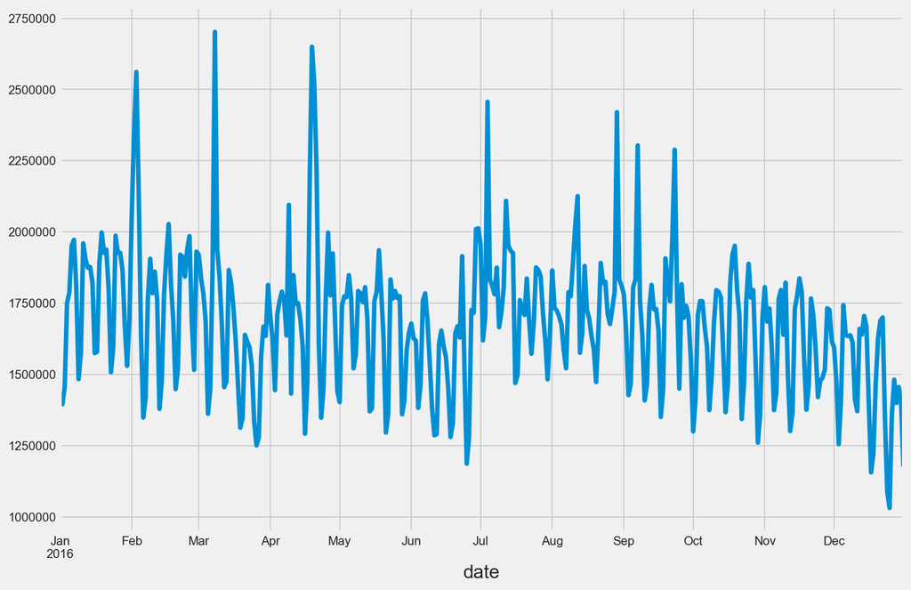

```python
ts_no_outliers2 = ts.copy()
ts_no_outliers2[ts_no_outliers2>0.3e7] = imputes

ts_no_outliers2.plot()
```

# Modelling Timeseries

## Modelling: ARIMA for non-seasonal timeseries

ARIMA(pdq)

AR - auto regressive (p for past day effect)  
I - integrated (d for differencing)  
MA - moving averge (q for fluctuations errors)

stationary = mean, variance does not change over time

To make a timeseries stationary we can use differencing:

```
differencing: ydiff(t) = y(t) - y(t-1)
first order : ydiff1   = y(t) - y(t-1)
second order: ydiff2   = ydiff(t) - ydiff(t-1)
                       = [y(t) - y(t-1)] - [y(t-1) - y(t-2)]
                       = y(t) - 2y(t-1) + y(t-2)
```

Models:

```
T = trend
C = cycle
S = seasonality
R = residual

Additive model: Y = T + C + S + R
Multiplicative model: Y = T * C * S * R
```

References

- [selecting p,d,q](https://www.machinelearningplus.com/time-series/arima-model-time-series-forecasting-python/)

## Find Auto Regressive AR term p (partial correlation)

We can use Partial Autocorrelation (PACF) plot to estimate the autoregressive term p.

```python
def lag_plot_partial_autocorrelation():
    from statsmodels.graphics.tsaplots import plot_pacf

    for p in range(5):
        tsx = eval('ts' + '.diff()'*p + '.dropna()')
        fig = plot_pacf(tsx)
        plt.title(f'Partial Autocorrelation for lag p= {p}')
        plt.xticks(range(25))

# lag_plot_partial_autocorrelation()

# for 1st differencing p =1, most of the lines are almost inside
# the significance limit.
# we can choose p = 1 to start with.
```

## Find Integrated I term d (differentiation autocorrelation)

```python
def lag_plot_autocorrelation():
    from statsmodels.graphics.tsaplots import plot_acf

    for d in range(10):
        tsx = eval('ts' + '.diff()'*d + '.dropna()')
        fig = plot_acf(tsx)
        plt.title(f'Autocorrelation for lag d= {d}')
        plt.xticks(range(25))

# lag_plot_autocorrelation()

# I see that lag of d=7 gives similar lines above and below te base line.
# d=7, ie. weekly differencing is a good start.
```

```python
# https://www.alkaline-ml.com/pmdarima/modules/generated/pmdarima.arima.ndiffs.html
import six
from pmdarima.arima.utils import ndiffs


## augmented DF Test
adf = ndiffs(ts, test='adf')

# KPSS test
kpss = ndiffs(ts, test='kpss')

# PP test:
pp = ndiffs(ts, test='pp')

adf, kpss, pp
```

```
(0, 0, 0)
```

```python
# it shows that our time series is already stationary at no lagging.
# so, d =0 is a good start.
```

## Find Moving Average MA term q

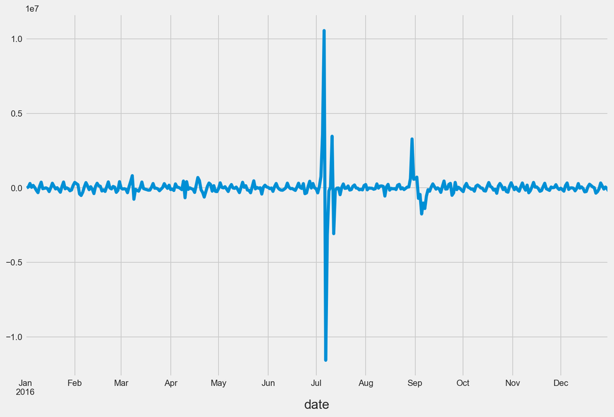

```python
from statsmodels.graphics.tsaplots import plot_acf

ts.diff().plot()
```

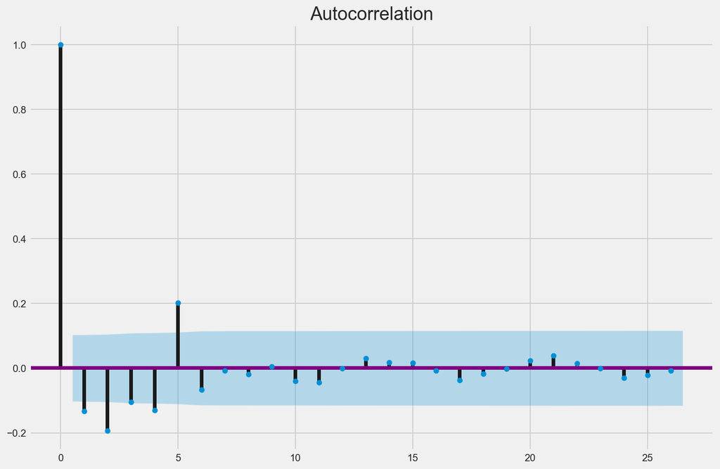

```python
plot_acf(ts.diff().dropna());
```

```python
# only few lags are above the significance region. so, choose q = 2.
# when in doubt choose simpler model.
```